# ECO 602 - Analysis of Environmental Data

## Model Diagnostics

### Residuals Histograms

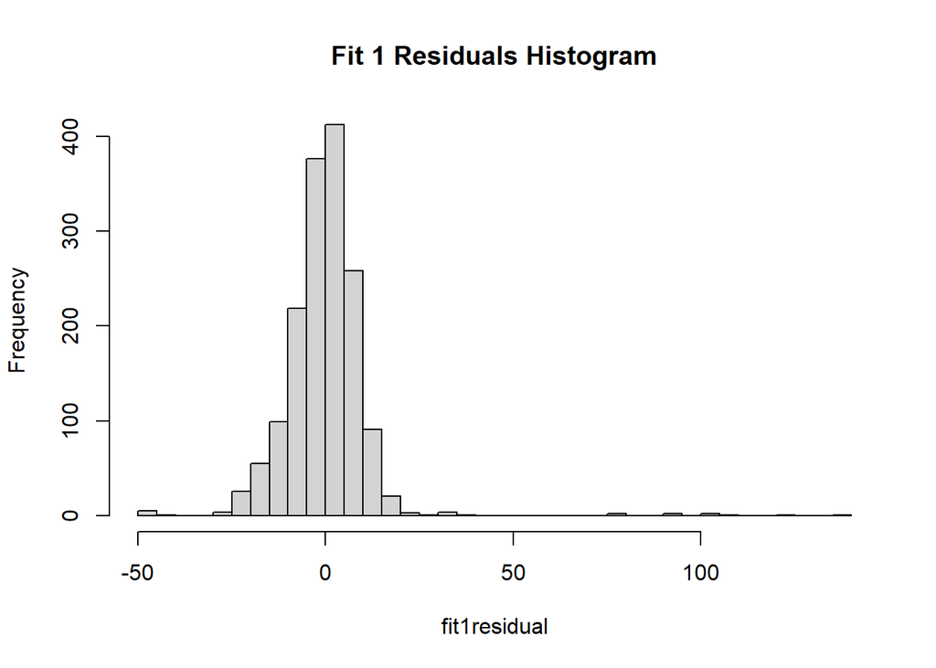

```r
fit1residual <- residuals(fit1) #Body mass to body length
fit2residual <- residuals(fit2)
fit3residual <- residuals(fit3)
fit4residual <- residuals(fit4)
fit5residual <- residuals(fit5)

hist(fit1residual, breaks = 30, main = "Fit 1 Residuals Histogram")
```

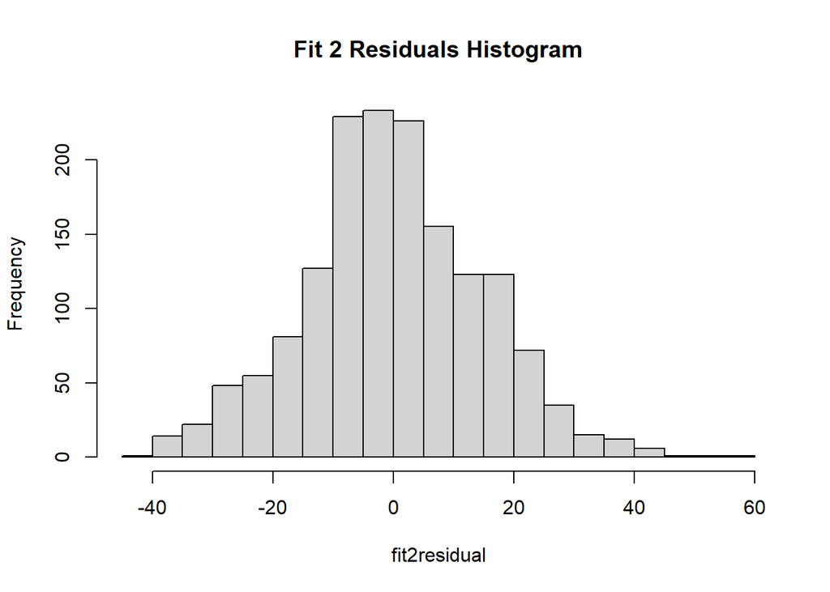

```r
hist(fit2residual, breaks = 30, main = "Fit 2 Residuals Histogram")
```

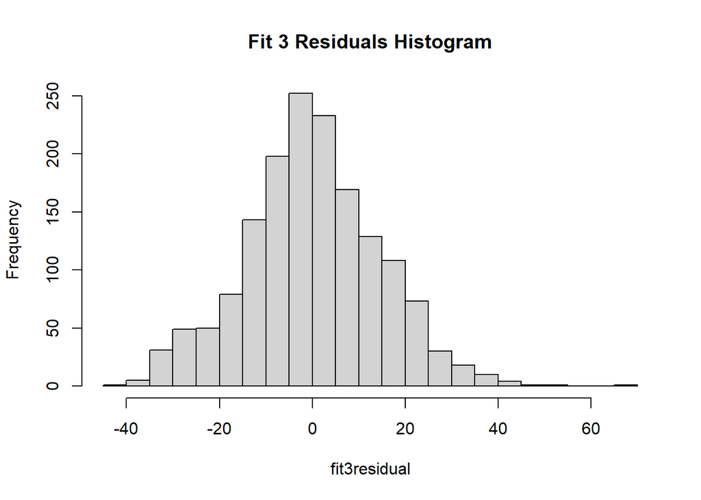

```r
hist(fit3residual, breaks = 30, main = "Fit 3 Residuals Histogram")
```

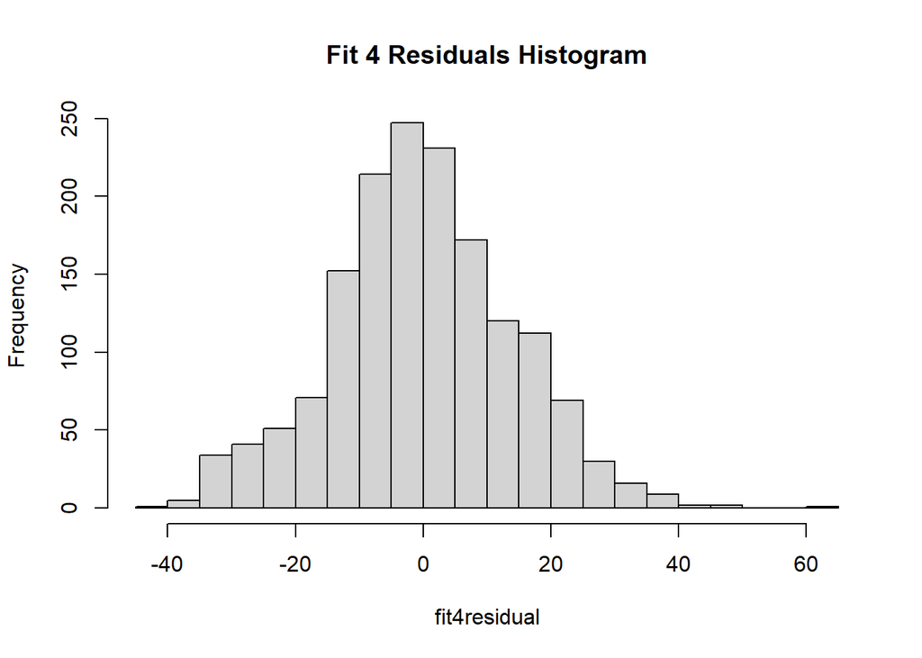

```r
hist(fit4residual, breaks = 30, main = "Fit 4 Residuals Histogram")
```

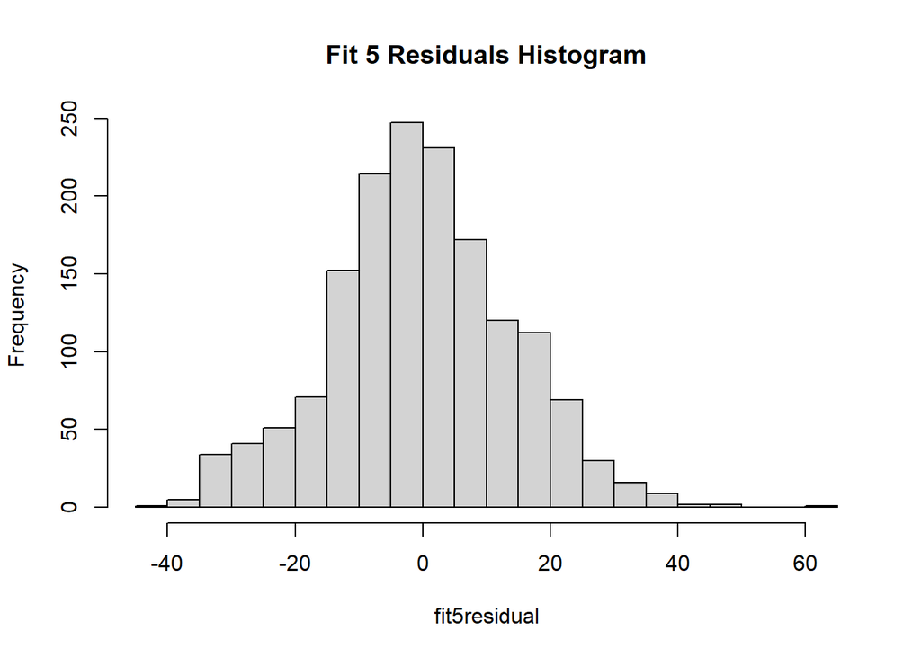

```r
hist(fit5residual, breaks = 30, main = "Fit 5 Residuals Histogram")
```

### Shapiro Tests

```r
shapiro.test(fit1residual)
```

```
##
##  Shapiro-Wilk normality test
##
## data:  fit1residual
## W = 0.73462, p-value < 2.2e-16
```

```r
shapiro.test(fit2residual)
```

```
##
##  Shapiro-Wilk normality test
##
## data:  fit2residual
## W = 0.99563, p-value = 0.0001541
```

```r
shapiro.test(fit3residual)
```

```
##
##  Shapiro-Wilk normality test
##
## data:  fit3residual
## W = 0.99535, p-value = 8.103e-05
```

```r
shapiro.test(fit4residual)
```

```
##
##  Shapiro-Wilk normality test
##
## data:  fit4residual
## W = 0.99525, p-value = 6.805e-05
```

```r
shapiro.test(fit5residual)
```

```
##
##  Shapiro-Wilk normality test
##
## data:  fit5residual
## W = 0.99526, p-value = 6.816e-05
```

### Questions

Question 1:

- What do you conclude about residual normality based on the numerical and graphical diagnostics?

  From a graphical standpoint, all of the histograms appear to have a normal distribution with the exception of fit1residual. From a numerical standpoint, the shapiro test shows all p-values below 0.05. This rejects the hypothesis of normal distribution posed by the shapiro-Wilk test.

Question 2:

- Are violations of the normality assumption equally severe for all the models?

  While all of the fitresidual shapiro tests show a non normal distribution, the p- vlaues differ in severity which indicates varying degree’s of non normality. For instance, the shapiro test for fit1residual has a much smaller p-value which indicates that this distribution is less normally distributed compared to fitresiduals 2 through 5.

## Model Interpretation

Printing Coefficient table

```r
knitr::kable(coef(summary(fit1)))
```

|  | Estimate | Std. Error | t value | Pr(>\|t\|) |
| --- | --- | --- | --- | --- |
| (Intercept) | 76.1246565 | 0.9158120 | 83.12258 | 0 |
| body_mass | 0.8754988 | 0.0196905 | 44.46298 | 0 |

```r
knitr::kable(coef(summary(fit2)))
```

|  | Estimate | Std. Error | t value | Pr(>\|t\|) |
| --- | --- | --- | --- | --- |
| (Intercept) | 42.711465 | 0.5288929 | 80.756355 | 0.0000000 |
| sexmale | 2.784133 | 0.7456117 | 3.734024 | 0.0001951 |

```r
knitr::kable(coef(summary(fit3)))
```

|  | Estimate | Std. Error | t value | Pr(>\|t\|) |
| --- | --- | --- | --- | --- |
| (Intercept) | 46.752427 | 0.4499933 | 103.89582 | 0 |
| binomialDelomys sublineatus | -7.683058 | 0.7604562 | -10.10322 | 0 |

```r
knitr::kable(coef(summary(fit4)))
```

|  | Estimate | Std. Error | t value | Pr(>\|t\|) |
| --- | --- | --- | --- | --- |
| (Intercept) | 45.070355 | 0.5556429 | 81.113891 | 0e+00 |
| sexmale | 3.795395 | 0.7259609 | 5.228099 | 2e-07 |
| binomialDelomys sublineatus | -8.193492 | 0.7609985 | -10.766764 | 0e+00 |

```r
knitr::kable(coef(summary(fit5)))
```

|  | Estimate | Std. Error | t value | Pr(>\|t\|) |
| --- | --- | --- | --- | --- |
| (Intercept) | 45.0554562 | 0.6052973 | 74.4352459 | 0.0000000 |
| sexmale | 3.8280908 | 0.8966667 | 4.2692460 | 0.0000208 |
| binomialDelomys sublineatus | -8.1417394 | 1.1281046 | -7.2171847 | 0.0000000 |
| sexmale:binomialDelomys sublineatus | -0.0950187 | 1.5285856 | -0.0621612 | 0.9504424 |

### Body Length Questions:

```r
#Model Coefficient Table Body Length~Body Mass. Intercept = Body Length
knitr::kable(coef(summary(fit1)))
```

|  | Estimate | Std. Error | t value | Pr(>\|t\|) |
| --- | --- | --- | --- | --- |
| (Intercept) | 76.1246565 | 0.9158120 | 83.12258 | 0 |
| body_mass | 0.8754988 | 0.0196905 | 44.46298 | 0 |

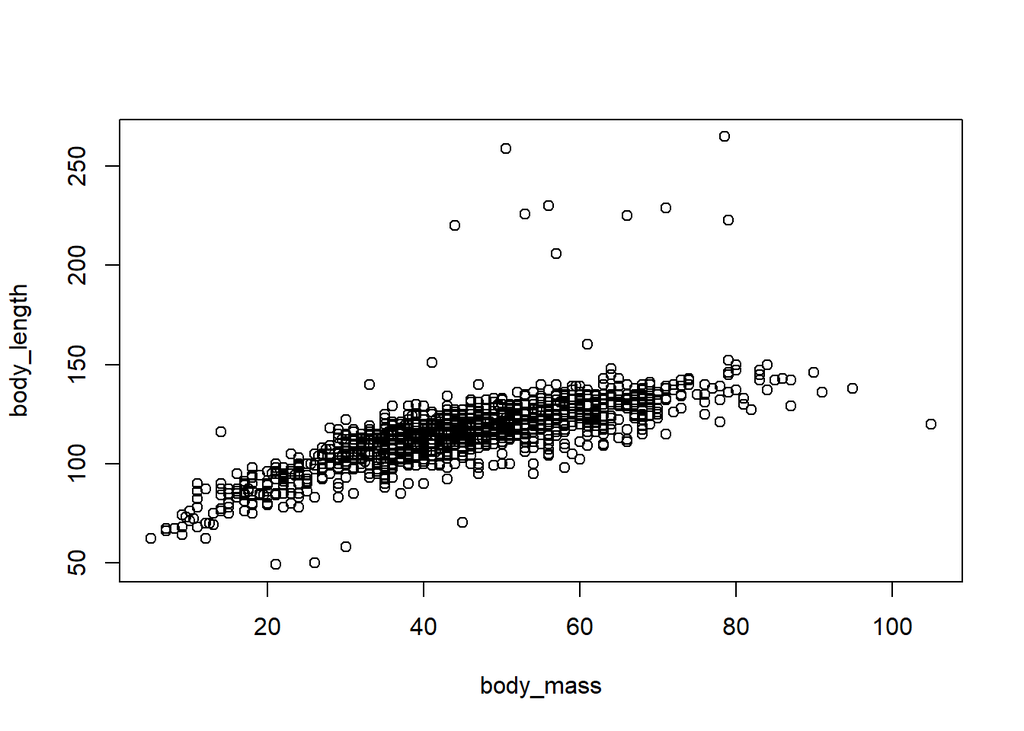

```r
#Scatter Plot Body Length~Body Mass
plot(body_length~body_mass, data = delomys)
```

Question 1:

- What is the magnitude of the mass/length relationship?

  Magnitude is represented by the slope.

Question 2:

- What is the expected body length of an an animal that weighs 100g?

Question 3:

- What is the expected body length of an animal that weighs 0g?

### Body Mass Coefficients Questions

Body Mass and Sex:

```r
knitr::kable(coef(summary(fit2)))
```

|  | Estimate | Std. Error | t value | Pr(>\|t\|) |
| --- | --- | --- | --- | --- |
| (Intercept) | 42.711465 | 0.5288929 | 80.756355 | 0.0000000 |
| sexmale | 2.784133 | 0.7456117 | 3.734024 | 0.0001951 |

Question 1:

- What is the base level for sex?

  The base is 42.711465

```r
knitr::kable(coef(summary(fit3)))
```

|  | Estimate | Std. Error | t value | Pr(>\|t\|) |
| --- | --- | --- | --- | --- |
| (Intercept) | 46.752427 | 0.4499933 | 103.89582 | 0 |
| binomialDelomys sublineatus | -7.683058 | 0.7604562 | -10.10322 | 0 |

Question 2:

- What is the base level for binomial?

  The base is 46.752427

Question 3:

- Which sex is heavier?

  The Males

Question 4:

- Which species is heavier?

  Delomy Dorsalis is the heavier species.

### ANOVA: Coefficients Questions

Question 1:

- Are sex and species significant predictors for body mass?

  Yes, since the p value is less than 0.05.

Question 2:

- Is there a significant interaction?

  There no significant interaction

Question 3:

- Does the significance (as measured by p-value) of either of the main effects (sex and species) differ much between the single-predictor models, the additive model, and the interactive model?

  No they don’t.

## Model Comparison

```r
AIC(fit1)
```

```
## [1] 12291.67
```

```r
AIC(fit2)
```

```
## [1] 13006.8
```

```r
AIC(fit3)
```

```
## [1] 12966.36
```

```r
AIC(fit4)
```

```
## [1] 12896.73
```

```r
AIC(fit5)
```

```
## [1] 12898.72
```

Question 1:

- Which two models have the lowest AIC?

Question 2:

- Which of the two models with lowest AIC scores would you select? Explain your decision based on model fit and the complexity/understanding tradeoff.